# HW 7 - KELLY “SCOTT” SIMS

### Always shutdown your h2o instances when done

```r
h2o.shutdown(prompt = FALSE)
```

```
Error in h2o.shutdown(prompt = FALSE) : There is no H2O instance running.
```

Question 10.2 Describe a situation or problem from your job, everyday life, current events, etc., for which a logistic regression model would be appropriate. List some (up to 5) predictors that you might use.

> Logistic Regression models are used today in the medical field in order to determine if a patient’s tumor is benign or malignant. Various features can be used in the model to predict one of the binary classes. Such as: 1. Age of patient 2. Gender 3. Family history with cancer 4. Length of tumor 5. Width of tumor 6. Any image indicators from CT and/or Sonograph

Using the GermanCredit data set germancredit.txt from http://archive.ics.uci.edu/ml/machine-learning-databases/statlog/german / (description at http://archive.ics.uci.edu/ml/datasets/Statlog+%28German+Credit+Data%29 ), use logistic regression to find a good predictive model for whether credit applicants are good credit risks or not. Show your model (factors used and their coefficients), the software output, and the quality of fit. You can use the glm function in R. To get a logistic regression (logit) model on data where the response is either zero or one, use family=binomial(link=”logit”) in your glm function call.

### Load the data

```r
gc_data <- read.table('germancredit.txt', header = FALSE, stringsAsFactors = TRUE)
gc_data$V21 <- as.factor(gc_data$V21)
head(gc_data)
```

|  | V1 | V2 | V3 | V4 | V5 | V6 | V7 | V8 | V9 | V10 | V11 | V12 | V13 | V14 | V15 | V16 | V17 | V18 | V19 | V20 | V21 |
| --- | --- | --- | --- | --- | --- | --- | --- | --- | --- | --- | --- | --- | --- | --- | --- | --- | --- | --- | --- | --- | --- |
| 1 | A11 | 6 | A34 | A43 | 1169 | A65 | A75 | 4 | A93 | A101 | 4 | A121 | 67 | A143 | A152 | 2 | A173 | 1 | A192 | A201 | 1 |
| 2 | A12 | 48 | A32 | A43 | 5951 | A61 | A73 | 2 | A92 | A101 | 2 | A121 | 22 | A143 | A152 | 1 | A173 | 1 | A191 | A201 | 2 |
| 3 | A14 | 12 | A34 | A46 | 2096 | A61 | A74 | 2 | A93 | A101 | 3 | A121 | 49 | A143 | A152 | 1 | A172 | 2 | A191 | A201 | 1 |
| 4 | A11 | 42 | A32 | A42 | 7882 | A61 | A74 | 2 | A93 | A103 | 4 | A122 | 45 | A143 | A153 | 1 | A173 | 2 | A191 | A201 | 1 |
| 5 | A11 | 24 | A33 | A40 | 4870 | A61 | A73 | 3 | A93 | A101 | 4 | A124 | 53 | A143 | A153 | 2 | A173 | 2 | A191 | A201 | 2 |
| 6 | A14 | 36 | A32 | A46 | 9055 | A65 | A73 | 2 | A93 | A101 | 4 | A124 | 35 | A143 | A153 | 1 | A172 | 2 | A192 | A201 | 1 |

```r
summary(gc_data)
```

```
   V1            V2         V3            V4            V5
 A11:274   Min.   : 4.0   A30: 40   A43    :280   Min.   :  250
 A12:269   1st Qu.:12.0   A31: 49   A40    :234   1st Qu.: 1366
 A13: 63   Median :18.0   A32:530   A42    :181   Median : 2320
 A14:394   Mean   :20.9   A33: 88   A41    :103   Mean   : 3271
           3rd Qu.:24.0   A34:293   A49    : 97   3rd Qu.: 3972
           Max.   :72.0             A46    : 50   Max.   :18424
                                    (Other): 55
   V6        V7            V8          V9        V10
 A61:603   A71: 62   Min.   :1.000   A91: 50   A101:907
 A62:103   A72:172   1st Qu.:2.000   A92:310   A102: 41
 A63: 63   A73:339   Median :3.000   A93:548   A103: 52
 A64: 48   A74:174   Mean   :2.973   A94: 92
 A65:183   A75:253   3rd Qu.:4.000
                     Max.   :4.000

      V11          V12           V13          V14        V15
 Min.   :1.000   A121:282   Min.   :19.00   A141:139   A151:179
 1st Qu.:2.000   A122:232   1st Qu.:27.00   A142: 47   A152:713
 Median :3.000   A123:332   Median :33.00   A143:814   A153:108
 Mean   :2.845   A124:154   Mean   :35.55
 3rd Qu.:4.000              3rd Qu.:42.00
 Max.   :4.000              Max.   :75.00

      V16          V17           V18          V19        V20
 Min.   :1.000   A171: 22   Min.   :1.000   A191:596   A201:963
 1st Qu.:1.000   A172:200   1st Qu.:1.000   A192:404   A202: 37
 Median :1.000   A173:630   Median :1.000
 Mean   :1.407   A174:148   Mean   :1.155
 3rd Qu.:2.000              3rd Qu.:1.000
 Max.   :4.000              Max.   :2.000

 V21
 1:700
 2:300
```

Looking at the summary of the data, we can see that there is a mix between numerical columns and categorical columns. We set the “stringAsFacotrs” as TRUE. This is R’s way of converting string columns into categorical variables to be handled in the model. For instances, we can see how R is going to categorize the first column

```r
contrasts(gc_data$V1)
```

```
    A12 A13 A14
A11   0   0   0
A12   1   0   0
A13   0   1   0
A14   0   0   1
```

We can see that entries of A11 will be encoded as (0,0,0), A12 will be encoded as (1,0,0), A13 will be encoded as (0,1,0) etc.

### Train / Test Split of data

```r
set.seed(42)
sample = sample.split(gc_data, SplitRatio = .8)
train = subset(gc_data, sample == TRUE)
test = subset(gc_data, sample == FALSE)
```

### Fit the Model

```r
gc_model <- glm(V21 ~., family = binomial(link='logit'), data = train)
summary(gc_model)
```

```
Call:
glm(formula = V21 ~ ., family = binomial(link = "logit"), data = train)

Deviance Residuals:
    Min       1Q   Median       3Q      Max
-2.4184  -0.6750  -0.3459   0.6592   2.5177

Coefficients:
              Estimate Std. Error z value Pr(>|z|)
(Intercept)  2.006e+00  1.259e+00   1.593 0.111148
V1A12       -2.226e-01  2.583e-01  -0.862 0.388776
V1A13       -1.029e+00  4.404e-01  -2.336 0.019480 *
V1A14       -1.583e+00  2.750e-01  -5.758 8.49e-09 ***
V2           3.344e-02  1.105e-02   3.025 0.002485 **
V3A31       -5.816e-01  6.683e-01  -0.870 0.384150
V3A32       -1.367e+00  5.352e-01  -2.555 0.010618 *
V3A33       -1.544e+00  5.816e-01  -2.655 0.007934 **
V3A34       -2.114e+00  5.486e-01  -3.853 0.000117 ***
V4A41       -1.812e+00  4.401e-01  -4.118 3.83e-05 ***
V4A410      -2.171e+00  1.030e+00  -2.107 0.035102 *
V4A42       -9.321e-01  3.041e-01  -3.064 0.002180 **
V4A43       -1.196e+00  2.971e-01  -4.028 5.63e-05 ***
V4A44       -1.494e+01  5.668e+02  -0.026 0.978970
V4A45       -2.916e-01  6.728e-01  -0.433 0.664735
V4A46       -3.416e-01  4.360e-01  -0.784 0.433248
V4A48       -2.032e+00  1.291e+00  -1.574 0.115486
V4A49       -1.356e+00  4.025e-01  -3.368 0.000756 ***
V5           1.277e-04  5.152e-05   2.478 0.013195 *
V6A62       -3.780e-01  3.427e-01  -1.103 0.269987
V6A63       -2.668e-01  4.490e-01  -0.594 0.552370
V6A64       -1.626e+00  6.391e-01  -2.544 0.010954 *
V6A65       -1.024e+00  3.075e-01  -3.330 0.000870 ***
V7A72        1.769e-01  5.172e-01   0.342 0.732308
V7A73       -3.159e-01  4.989e-01  -0.633 0.526604
V7A74       -6.559e-01  5.264e-01  -1.246 0.212760
V7A75       -2.303e-02  5.013e-01  -0.046 0.963362
V8           2.814e-01  1.025e-01   2.747 0.006018 **
V9A92       -1.561e-01  4.534e-01  -0.344 0.730539
V9A93       -9.241e-01  4.508e-01  -2.050 0.040378 *
V9A94       -3.761e-01  5.426e-01  -0.693 0.488209
```

[output cut: 13 more lines]

```
V17A173      8.804e-02  7.682e-01   0.115 0.908756
V17A174      1.377e-01  7.722e-01   0.178 0.858504
V18          4.943e-01  2.865e-01   1.725 0.084542 .
V19A192     -4.104e-01  2.385e-01  -1.720 0.085348 .
V20A202     -2.381e+00  1.079e+00  -2.207 0.027345 *
---
Signif. codes:  0 ‘***’ 0.001 ‘**’ 0.01 ‘*’ 0.05 ‘.’ 0.1 ‘ ’ 1

(Dispersion parameter for binomial family taken to be 1)

    Null deviance: 926.51  on 761  degrees of freedom
Residual deviance: 655.17  on 713  degrees of freedom
AIC: 753.17

Number of Fisher Scoring iterations: 14
```

### ANOVA CHI SQUARED TEST

Next we will compare our model to the “NULL MODEL” (intercept only model). By using a chi squared test, we want to see how the deviance in residuals change as we add each feature one by one. We want to see an increase in difference between our model and the “NULL MODEL”

```r
anova(gc_model, test = "Chisq")
```

```
Analysis of Deviance Table

Model: binomial, link: logit

Response: V21

Terms added sequentially (first to last)

     Df Deviance Resid. Df Resid. Dev  Pr(>Chi)
NULL                   761     926.51
V1    3   97.426       758     829.08 < 2.2e-16 ***
V2    1   26.138       757     802.94 3.179e-07 ***
V3    4   26.406       753     776.54 2.621e-05 ***
V4    9   30.846       744     745.69 0.0003146 ***
V5    1    0.914       743     744.78 0.3390073
V6    4   17.667       739     727.11 0.0014336 **
V7    4   15.419       735     711.69 0.0039061 **
V8    1    4.732       734     706.96 0.0296098 *
V9    3   12.828       731     694.13 0.0050234 **
V10   2    4.746       729     689.39 0.0932197 .
V11   1    0.020       728     689.37 0.8874504
V12   3    2.048       725     687.32 0.5625475
V13   1    2.648       724     684.67 0.1036970
V14   2   10.605       722     674.07 0.0049787 **
V15   2    3.926       720     670.14 0.1404427
V16   1    0.593       719     669.55 0.4414465
V17   3    0.190       716     669.36 0.9791643
V18   1    3.153       715     666.21 0.0757922 .
V19   1    2.497       714     663.71 0.1140365
V20   1    8.539       713     655.17 0.0034755 **
---
Signif. codes:  0 ‘***’ 0.001 ‘**’ 0.01 ‘*’ 0.05 ‘.’ 0.1 ‘ ’ 1
```

### Model Accuracy

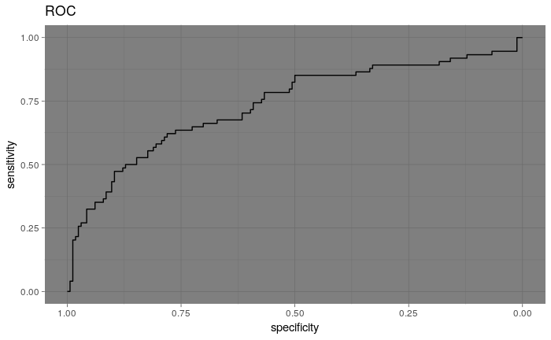

```r
test_predict <- predict(gc_model, newdata = test[,1:20], type ='response')
ROC <- roc(test$V21, test_predict)
ggroc(ROC) + theme_dark() + ggtitle('ROC')
```

```r
print(paste('AUC: ', auc(ROC)))
```

```
[1] "AUC:  0.734426499670402"
```

```r
test_predict <- ifelse(test_predict > 0.20, 2, 1)
confusionMatrix(as.factor(test_predict), as.factor(test$V21), positive = '2')
```

```
Confusion Matrix and Statistics

          Reference
Prediction  1  2
         1 99 22
         2 65 52

               Accuracy : 0.6345
                 95% CI : (0.5698, 0.6957)
    No Information Rate : 0.6891
    P-Value [Acc > NIR] : 0.9693

                  Kappa : 0.2642
 Mcnemar's Test P-Value : 6.704e-06

            Sensitivity : 0.7027
            Specificity : 0.6037
         Pos Pred Value : 0.4444
         Neg Pred Value : 0.8182
             Prevalence : 0.3109
         Detection Rate : 0.2185
   Detection Prevalence : 0.4916
      Balanced Accuracy : 0.6532

       'Positive' Class : 2
```

### Tuning

From our Chi Square test results, let’s use the most statitically significant features from that test.

1. V1 - Status of existing checking
2. V2 - Duration in month
3. V3 - Credit History
4. V4 - Purpose
5. V6 - Savings Account balance
6. V7 - Present Employment
7. V9 - Personal Status and Sex
8. V14 - Other installment plans
9. V20 - Foreign Worker

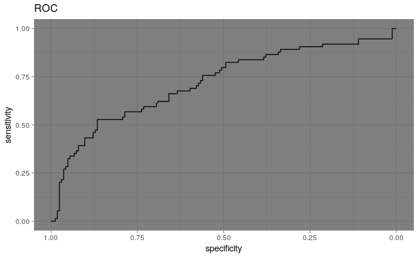

```r
train_final <- train[, c(1,2,3,4,6,7,9,14,20,21)]
test_final <- test[, c(1,2,3,4,6,7,9,14,20,21)]
final_model <- glm(V21 ~., family = binomial(link='logit'), data = train_final)
final_predict <- predict(final_model, newdata = test_final, type ='response')
final_ROC <- roc(test_final$V21, final_predict)
ggroc(final_ROC) + theme_dark() + ggtitle('ROC')
```

```r
print(paste('AUC: ', auc(ROC)))
```

```
[1] "AUC:  0.734426499670402"
```

```r
final_predict <- ifelse(final_predict > 0.15, 2, 1)
confusionMatrix(as.factor(final_predict), as.factor(test_final$V21), positive = '2')
```

```
Confusion Matrix and Statistics

          Reference
Prediction  1  2
         1 85 17
         2 79 57

               Accuracy : 0.5966
                 95% CI : (0.5313, 0.6595)
    No Information Rate : 0.6891
    P-Value [Acc > NIR] : 0.999

                  Kappa : 0.2346
 Mcnemar's Test P-Value : 4.791e-10

            Sensitivity : 0.7703
            Specificity : 0.5183
         Pos Pred Value : 0.4191
         Neg Pred Value : 0.8333
             Prevalence : 0.3109
         Detection Rate : 0.2395
   Detection Prevalence : 0.5714
      Balanced Accuracy : 0.6443

       'Positive' Class : 2
```

Conclusion: After playing around with several probability thresholds, with the “tuned” model, it still couldn’t quite get to the results of the all variables model. Therefore, we will express the answer in terms of the all variables model

### Model Coeficients

```r
coef = as.matrix(gc_model$coefficients)
coef
```

```
                     [,1]
(Intercept)  2.005960e+00
V1A12       -2.226314e-01
V1A13       -1.028931e+00
V1A14       -1.583297e+00
V2           3.343583e-02
V3A31       -5.816336e-01
V3A32       -1.367420e+00
V3A33       -1.544016e+00
V3A34       -2.113856e+00
V4A41       -1.811993e+00
V4A410      -2.171294e+00
V4A42       -9.320606e-01
V4A43       -1.196399e+00
V4A44       -1.494222e+01
V4A45       -2.916034e-01
V4A46       -3.416328e-01
V4A48       -2.031583e+00
V4A49       -1.355907e+00
V5           1.276948e-04
V6A62       -3.779772e-01
V6A63       -2.667757e-01
V6A64       -1.626021e+00
V6A65       -1.023886e+00
V7A72        1.768956e-01
V7A73       -3.159155e-01
V7A74       -6.558751e-01
V7A75       -2.302906e-02
V8           2.814237e-01
V9A92       -1.561413e-01
V9A93       -9.240783e-01
V9A94       -3.760751e-01
V10A102      4.432319e-01
V10A103     -8.264608e-01
V11         -3.811712e-02
V12A122      4.634545e-02
V12A123     -2.952799e-02
V12A124      6.496454e-01
V13         -1.439163e-02
V14A142      1.573682e-01
V14A143     -7.768228e-01
V15A152     -5.517392e-01
V15A153     -6.840414e-01
V16          1.479307e-01
V17A172      5.988959e-03
V17A173      8.804191e-02
V17A174      1.376658e-01
V18          4.942606e-01
V19A192     -4.103831e-01
V20A202     -2.380572e+00
```

### Probablility Threshold

```r
cm <- confusionMatrix(as.factor(test_predict), as.factor(test$V21), positive = '2')
cm$table
```

```
          Reference
Prediction  1  2
         1 99 22
         2 65 52
```

A threshold of 20% gave the best results of limiting the 5x damage of incorrectly predicting a “bad credit risk”